# notebook_phase1

```python
import pandas as pd
import seaborn as sns
import matplotlib.pyplot as plt
import numpy as np
```

### EDA

```python
df = pd.read_csv("dataset/scaler_clustering.csv")
df.head()
```

|  | Unnamed: 0 | company_hash | email_hash | orgyear | ctc | job_position | ctc_updated_year |
| --- | --- | --- | --- | --- | --- | --- | --- |
| 0 | 0 | atrgxnnt xzaxv | 6de0a4417d18ab14334c3f43397fc13b30c35149d70c05... | 2016.0 | 1100000 | Other | 2020.0 |
| 1 | 1 | qtrxvzwt xzegwgbb rxbxnta | b0aaf1ac138b53cb6e039ba2c3d6604a250d02d5145c10... | 2018.0 | 449999 | FullStack Engineer | 2019.0 |
| 2 | 2 | ojzwnvwnxw vx | 4860c670bcd48fb96c02a4b0ae3608ae6fdd98176112e9... | 2015.0 | 2000000 | Backend Engineer | 2020.0 |
| 3 | 3 | ngpgutaxv | effdede7a2e7c2af664c8a31d9346385016128d66bbc58... | 2017.0 | 700000 | Backend Engineer | 2019.0 |
| 4 | 4 | qxen sqghu | 6ff54e709262f55cb999a1c1db8436cb2055d8f79ab520... | 2017.0 | 1400000 | FullStack Engineer | 2019.0 |

```python
df.shape
```

```
(205843, 7)
```

```python
df.info()
```

```
<class 'pandas.core.frame.DataFrame'>
RangeIndex: 205843 entries, 0 to 205842
Data columns (total 7 columns):
 #   Column            Non-Null Count   Dtype
---  ------            --------------   -----
 0   Unnamed: 0        205843 non-null  int64
 1   company_hash      205799 non-null  object
 2   email_hash        205843 non-null  object
 3   orgyear           205757 non-null  float64
 4   ctc               205843 non-null  int64
 5   job_position      153279 non-null  object
 6   ctc_updated_year  205843 non-null  float64
dtypes: float64(2), int64(2), object(3)
memory usage: 11.0+ MB
```

```python
df.drop(columns=["Unnamed: 0"], axis=1, inplace=True)
```

```python
df.describe()
```

|  | orgyear | ctc | ctc_updated_year |
| --- | --- | --- | --- |
| count | 205757.000000 | 2.058430e+05 | 205843.000000 |
| mean | 2014.882750 | 2.271685e+06 | 2019.628231 |
| std | 63.571115 | 1.180091e+07 | 1.325104 |
| min | 0.000000 | 2.000000e+00 | 2015.000000 |
| 25% | 2013.000000 | 5.300000e+05 | 2019.000000 |
| 50% | 2016.000000 | 9.500000e+05 | 2020.000000 |
| 75% | 2018.000000 | 1.700000e+06 | 2021.000000 |
| max | 20165.000000 | 1.000150e+09 | 2021.000000 |

```python
df['orgyear'] = df['orgyear'].astype("object")
df["ctc_updated_year"] = df["ctc_updated_year"].astype("object")
```

```python
df.describe()
```

|  | ctc |
| --- | --- |
| count | 2.058430e+05 |
| mean | 2.271685e+06 |
| std | 1.180091e+07 |
| min | 2.000000e+00 |
| 25% | 5.300000e+05 |
| 50% | 9.500000e+05 |
| 75% | 1.700000e+06 |
| max | 1.000150e+09 |

```python
df.describe(include="object")
```

|  | company_hash | email_hash | orgyear | job_position | ctc_updated_year |
| --- | --- | --- | --- | --- | --- |
| count | 205799 | 205843 | 205757.0 | 153279 | 205843.0 |
| unique | 37299 | 153443 | 77.0 | 1016 | 7.0 |
| top | nvnv wgzohrnvzwj otqcxwto | bbace3cc586400bbc65765bc6a16b77d8913836cfc98b7... | 2018.0 | Backend Engineer | 2019.0 |
| freq | 8337 | 10 | 25256.0 | 43554 | 68688.0 |

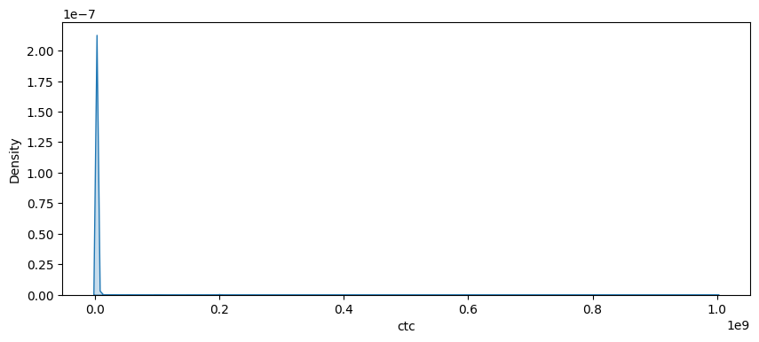

```python
fig=plt.figure(figsize=(10,4)) # width*height

# Create a KDE plot with filtered data
plt.subplot(1,1,1)
sns.kdeplot(df["ctc"], fill=True)
```

- CTC seems to have outliers, we will be handling the same while working further.
- note: outliers doesn't mean that they are noise, in case of income we may have people with expemtional income.

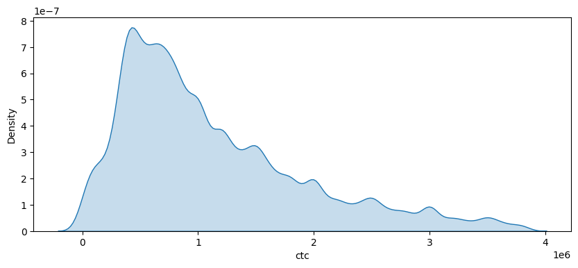

```python
fig=plt.figure(figsize=(10,4)) # width*height

# Get the data
data = df['ctc']

# Set a range to exclude outliers (adjust as needed)
lower_limit = np.percentile(data, 0)
upper_limit = np.percentile(data, 95)

# Filter the data to exclude outliers
filtered_data = data[(data >= lower_limit) & (data <= upper_limit)]

# Create a KDE plot with filtered data
plt.subplot(1,1,1)
sns.kdeplot(filtered_data, fill=True)
```

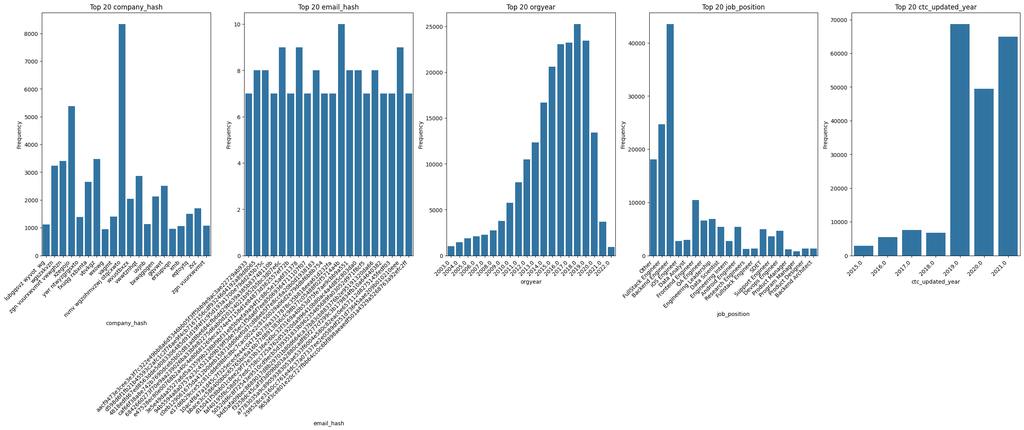

```python
fig=plt.figure(figsize=(32,8)) # width*height

for ind_num,col_name in enumerate(df.describe(include='object')):

    # get top n categories
    top_n = 20
    top_categories = df[col_name].value_counts().nlargest(top_n).index

    # filter the df
    df_top_n = df[df[col_name].isin(top_categories)]

    # Create a countplot
    plt.subplot(1,5,ind_num+1)
    sns.countplot(x=col_name, data=df_top_n)
    plt.xticks(rotation=45, ha='right')  # Rotate x-axis labels for better visibility

    # Set labels and title
    plt.xlabel(col_name)
    plt.ylabel('Frequency')
    plt.title(f'Top {top_n} {col_name}')
```

- Seems we have dubplicate entries for candidates in dataset having multiple years of experience.
- Last CTC update year was in 2021.

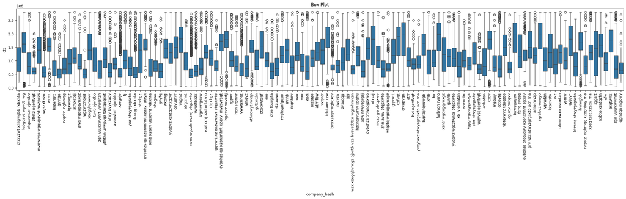

```python
# Categorical Vs Numerical (CTC)

fig=plt.figure(figsize=(100,4))

# Set a range to exclude outliers (adjust as needed)
lower_limit = np.percentile(df['ctc'], 1)
upper_limit = np.percentile(df['ctc'], 90)

# Filter the data to exclude outliers
filtered_data = df[(df['ctc'] >= lower_limit) & (df['ctc'] <= upper_limit)]

# get top n categories
top_n = 120
top_categories = filtered_data["company_hash"].value_counts().nlargest(top_n).index

# filter the df
df_top_n = filtered_data[filtered_data["company_hash"].isin(top_categories)]

plt.subplot(1,3,1)
sns.boxplot(y='ctc', x='company_hash', data=df_top_n)

plt.xticks(rotation=90, ha='center')  # Rotate x-axis labels for better visibility

# Set labels and title
plt.xlabel("company_hash")
plt.ylabel('ctc')
plt.title(f'Box Plot')
```

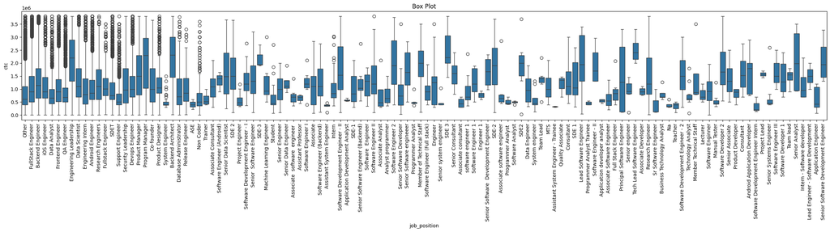

```python
fig=plt.figure(figsize=(100,4)) # width*height

# Set a range to exclude outliers (adjust as needed)
lower_limit = np.percentile(df['ctc'], 0)
upper_limit = np.percentile(df['ctc'], 95)

# Filter the data to exclude outliers
filtered_data = df[(df['ctc'] >= lower_limit) & (df['ctc'] <= upper_limit)]

# get top n categories
top_n = 120
top_categories = filtered_data["job_position"].value_counts().nlargest(top_n).index

# filter the df
df_top_n = filtered_data[filtered_data["job_position"].isin(top_categories)]

plt.subplot(1,3,1)
sns.boxplot(y='ctc', x='job_position', data=df_top_n)

plt.xticks(rotation=90, ha='center')  # Rotate x-axis labels for better visibility

# Set labels and title
plt.xlabel("job_position")
plt.ylabel('ctc')
plt.title(f'Box Plot')
```

- Profiles seems to earn more irrespective of which company they work for includes:
1. SDE-3
2. Tech Lead Software Engineer

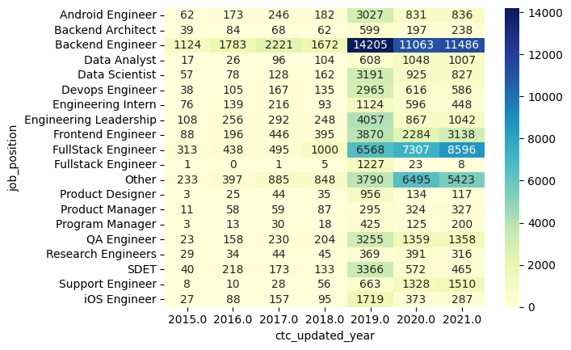

```python
# Category Vs Category

# get top n categories
top_n = 20
top_categories = df["job_position"].value_counts().nlargest(top_n).index

# filter the df
df_top_n = df[df["job_position"].isin(top_categories)]

cross_tab = pd.crosstab(df_top_n["job_position"], df_top_n["ctc_updated_year"])
sns.heatmap(cross_tab,annot=True, cmap="YlGnBu", fmt='d', cbar=True)
```

- Full Stack Engineers and Backend Engineer have higher chances of getting Appraisal or Salary hike as compare to other Profiles

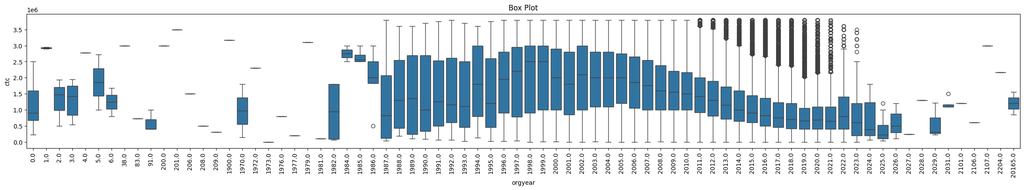

```python
fig=plt.figure(figsize=(100,4)) # width*height

# Set a range to exclude outliers (adjust as needed)
lower_limit = np.percentile(df['ctc'], 0)
upper_limit = np.percentile(df['ctc'], 95)

# Filter the data to exclude outliers
filtered_data = df[(df['ctc'] >= lower_limit) & (df['ctc'] <= upper_limit)]

# get top n categories
top_n = 120
top_categories = filtered_data["orgyear"].value_counts().nlargest(top_n).index

# filter the df
df_top_n = filtered_data[filtered_data["orgyear"].isin(top_categories)]

plt.subplot(1,3,1)
sns.boxplot(y='ctc', x='orgyear', data=df_top_n)

plt.xticks(rotation=90, ha='center')  # Rotate x-axis labels for better visibility

# Set labels and title
plt.xlabel("orgyear")
plt.ylabel('ctc')
plt.title(f'Box Plot')
```

- From above graph we have a lot of noise data, we'll be filter that later at pre-processing stage

```python
df['email_hash'].value_counts()[:10]
```

```
email_hash
bbace3cc586400bbc65765bc6a16b77d8913836cfc98b77c05488f02f5714a4b    10
3e5e49daa5527a6d5a33599b238bf9bf31e85b9efa9a94f1c88c5e15a6f31378     9
298528ce3160cc761e4dc37a07337ee2e0589df251d73645aae209b010210eee     9
6842660273f70e9aa239026ba33bfe82275d6ab0d20124021b952b5bc3d07e6c     9
d598d6f1fb21b45593c2afc1c2f76ae9f4cb7167156cdf93246d4192a89d8065     8
faf40195f8c58d5c7edc758cc725a762d51920da996410b80ac4a4d85c803da0     8
b4d5afa09bec8689017d8b29701b80d664ca37b83cb883376b2e95191320da66     8
d15041f58bb01c8ee29f72e33b136e26bc32f3169a40b53d75fe7ae9cbb9a551     8
4818edfd67ed8563dde5d083306485d91d19f4f1c95d193a1700e79dd245b75c     8
c0eb129061675da412b0deb15871dd06ef0d7cd86eb5f7e8cc6a20b0d1938183     8
Name: count, dtype: int64
```

```python
df[df['email_hash']=="bbace3cc586400bbc65765bc6a16b77d8913836cfc98b77c05488f02f5714a4b"]
```

|  | company_hash | email_hash | orgyear | ctc | job_position | ctc_updated_year |
| --- | --- | --- | --- | --- | --- | --- |
| 24109 | oxej ntwyzgrgsxto rxbxnta | bbace3cc586400bbc65765bc6a16b77d8913836cfc98b7... | 2018.0 | 720000 | NaN | 2020.0 |
| 45984 | oxej ntwyzgrgsxto rxbxnta | bbace3cc586400bbc65765bc6a16b77d8913836cfc98b7... | 2018.0 | 720000 | Support Engineer | 2020.0 |
| 72315 | oxej ntwyzgrgsxto rxbxnta | bbace3cc586400bbc65765bc6a16b77d8913836cfc98b7... | 2018.0 | 720000 | Other | 2020.0 |
| 102915 | oxej ntwyzgrgsxto rxbxnta | bbace3cc586400bbc65765bc6a16b77d8913836cfc98b7... | 2018.0 | 720000 | FullStack Engineer | 2020.0 |
| 117764 | oxej ntwyzgrgsxto rxbxnta | bbace3cc586400bbc65765bc6a16b77d8913836cfc98b7... | 2018.0 | 720000 | Data Analyst | 2020.0 |
| 121483 | oxej ntwyzgrgsxto rxbxnta | bbace3cc586400bbc65765bc6a16b77d8913836cfc98b7... | 2018.0 | 660000 | Other | 2019.0 |
| 124476 | oxej ntwyzgrgsxto rxbxnta | bbace3cc586400bbc65765bc6a16b77d8913836cfc98b7... | 2018.0 | 660000 | Support Engineer | 2019.0 |
| 144479 | oxej ntwyzgrgsxto rxbxnta | bbace3cc586400bbc65765bc6a16b77d8913836cfc98b7... | 2018.0 | 660000 | FullStack Engineer | 2019.0 |
| 152801 | oxej ntwyzgrgsxto rxbxnta | bbace3cc586400bbc65765bc6a16b77d8913836cfc98b7... | 2018.0 | 660000 | Devops Engineer | 2019.0 |
| 159835 | oxej ntwyzgrgsxto rxbxnta | bbace3cc586400bbc65765bc6a16b77d8913836cfc98b7... | 2018.0 | 660000 | NaN | 2019.0 |

- from above analysis we can check that candidate have multiple entries based on job_positions

```python
df[df['email_hash']=="d598d6f1fb21b45593c2afc1c2f76ae9f4cb7167156cdf93246d4192a89d8065"]
```

|  | company_hash | email_hash | orgyear | ctc | job_position | ctc_updated_year |
| --- | --- | --- | --- | --- | --- | --- |
| 4401 | nvnv wgzohrnvzwj otqcxwto | d598d6f1fb21b45593c2afc1c2f76ae9f4cb7167156cdf... | 2018.0 | 300000 | NaN | 2020.0 |
| 11331 | nvnv wgzohrnvzwj otqcxwto | d598d6f1fb21b45593c2afc1c2f76ae9f4cb7167156cdf... | 2018.0 | 300000 | Data Scientist | 2020.0 |
| 22412 | nvnv wgzohrnvzwj otqcxwto | d598d6f1fb21b45593c2afc1c2f76ae9f4cb7167156cdf... | 2018.0 | 300000 | Frontend Engineer | 2020.0 |
| 81028 | nvnv wgzohrnvzwj otqcxwto | d598d6f1fb21b45593c2afc1c2f76ae9f4cb7167156cdf... | 2018.0 | 400000 | Other | 2021.0 |
| 90782 | nvnv wgzohrnvzwj otqcxwto | d598d6f1fb21b45593c2afc1c2f76ae9f4cb7167156cdf... | 2018.0 | 400000 | Backend Engineer | 2021.0 |
| 92949 | nvnv wgzohrnvzwj otqcxwto | d598d6f1fb21b45593c2afc1c2f76ae9f4cb7167156cdf... | 2018.0 | 400000 | Data Scientist | 2021.0 |
| 107425 | nvnv wgzohrnvzwj otqcxwto | d598d6f1fb21b45593c2afc1c2f76ae9f4cb7167156cdf... | 2018.0 | 400000 | NaN | 2021.0 |
| 132398 | nvnv wgzohrnvzwj otqcxwto | d598d6f1fb21b45593c2afc1c2f76ae9f4cb7167156cdf... | 2018.0 | 400000 | Frontend Engineer | 2021.0 |

```python
df[df['email_hash']=="298528ce3160cc761e4dc37a07337ee2e0589df251d73645aae209b010210eee"]
```

|  | company_hash | email_hash | orgyear | ctc | job_position | ctc_updated_year |
| --- | --- | --- | --- | --- | --- | --- |
| 65909 | cvrhtbgbtznhb | 298528ce3160cc761e4dc37a07337ee2e0589df251d736... | 2018.0 | 720000 | Backend Engineer | 2020.0 |
| 72799 | cvrhtbgbtznhb | 298528ce3160cc761e4dc37a07337ee2e0589df251d736... | 2018.0 | 720000 | Research Engineers | 2020.0 |
| 82099 | cvrhtbgbtznhb | 298528ce3160cc761e4dc37a07337ee2e0589df251d736... | 2018.0 | 720000 | Other | 2020.0 |
| 93495 | cvrhtbgbtznhb | 298528ce3160cc761e4dc37a07337ee2e0589df251d736... | 2018.0 | 720000 | NaN | 2020.0 |
| 93783 | cvrhtbgbtznhb | 298528ce3160cc761e4dc37a07337ee2e0589df251d736... | 2018.0 | 720000 | Data Scientist | 2020.0 |
| 190903 | cvrhtbgbtznhb | 298528ce3160cc761e4dc37a07337ee2e0589df251d736... | 2018.0 | 700000 | Other | 2020.0 |
| 191498 | cvrhtbgbtznhb | 298528ce3160cc761e4dc37a07337ee2e0589df251d736... | 2018.0 | 700000 | Research Engineers | 2020.0 |
| 196685 | cvrhtbgbtznhb | 298528ce3160cc761e4dc37a07337ee2e0589df251d736... | 2018.0 | 700000 | Data Scientist | 2020.0 |
| 201587 | cvrhtbgbtznhb | 298528ce3160cc761e4dc37a07337ee2e0589df251d736... | 2018.0 | 700000 | Backend Engineer | 2020.0 |

```python
df_cnt = df['email_hash'].value_counts().reset_index()
df_cnt[df_cnt["count"]==2]['email_hash'].tolist()[:5]
```

```
['d3e27dfa3240546390161c8f8e7be3ea5cd8f47dbf7152c9df81f48dc841742e',
 '2dc0dd508944f55ff448d30a5e660174896c0de2d150e68941cf750bc5f1aa4a',
 '702b13ba2005b5dbe91e0b7a9e8c09b3d71bb84e468379e79fbb71c7615cfaaa',
 'd7df6bd598c376ae391518a835780f0bfac770b010c664ff3ba9fde097077ec6',
 '59f5ea9240dc8e6ba6790a2697c3e9b1605320851b816d7dd2211c102c6f21a6']
```

```python
df[df['email_hash']=="5559de74dd698c1ebc14d9653272d0c612970bc5ba206d6704394ccaab18c3cc"]
```

|  | company_hash | email_hash | orgyear | ctc | job_position | ctc_updated_year |
| --- | --- | --- | --- | --- | --- | --- |
| 34281 | qtamrvwpnqtt | 5559de74dd698c1ebc14d9653272d0c612970bc5ba206d... | 2019.0 | 600000 | NaN | 2021.0 |
| 184547 | ztnbtaowgb | 5559de74dd698c1ebc14d9653272d0c612970bc5ba206d... | 2019.0 | 340000 | FullStack Engineer | 2020.0 |

```python
df_cnt = df['email_hash'].value_counts().reset_index()
df_cnt[df_cnt["count"]==3]['email_hash'].tolist()[:5]
```

```
['7f9fd9949a7a90e322f3a1e72fb1eba7a1ae670778fe90d4a3a804ab87d7ae6a',
 'bf846924f9ebac3e7bd906316d7da0c0f16aab5b34d0d405c921917f4edd544c',
 '2538e1d0a89523f2a4a112e03b8d93e1b9f6a5d05a73fb2bc0cbe0bcb7ec395f',
 '8c7702516ea7c543e8f7758226a996c3bfbb6c889c432c27d1e9df6d34bcd8a8',
 '0d8e3ae92ca1e52184bb396d9ad92bbbbd6568bc579274ce9d2723ba380c8451']
```

```python
df[df['email_hash']=="6576d1f1a561eb06bce501ab7ece60baaee8d529902f16f12496a18a4287ff64"]
```

|  | company_hash | email_hash | orgyear | ctc | job_position | ctc_updated_year |
| --- | --- | --- | --- | --- | --- | --- |
| 83611 | vbvkgz | 6576d1f1a561eb06bce501ab7ece60baaee8d529902f16... | 2015.0 | 499999 | Other | 2020.0 |
| 96777 | vbvkgz | 6576d1f1a561eb06bce501ab7ece60baaee8d529902f16... | 2015.0 | 499999 | Data Analyst | 2020.0 |
| 162676 | vbvkgz | 6576d1f1a561eb06bce501ab7ece60baaee8d529902f16... | 2015.0 | 499999 | NaN | 2020.0 |

```python
df[df['email_hash']=="f6327cc669826a2b55dae0cbb69066a8e5e549320b73a6b0ce5cc9d5cc61c5ed"]
```

|  | company_hash | email_hash | orgyear | ctc | job_position | ctc_updated_year |
| --- | --- | --- | --- | --- | --- | --- |
| 41961 | vbtqxwvz tduqtoo | f6327cc669826a2b55dae0cbb69066a8e5e549320b73a6... | 2014.0 | 2000000 | NaN | 2021.0 |
| 56796 | vbtqxwvz tduqtoo | f6327cc669826a2b55dae0cbb69066a8e5e549320b73a6... | 2014.0 | 2000000 | Engineering Leadership | 2021.0 |
| 67497 | vbtqxwvz tduqtoo | f6327cc669826a2b55dae0cbb69066a8e5e549320b73a6... | 2014.0 | 2000000 | FullStack Engineer | 2021.0 |

```python
df.info()
```

```
<class 'pandas.core.frame.DataFrame'>
RangeIndex: 205843 entries, 0 to 205842
Data columns (total 6 columns):
 #   Column            Non-Null Count   Dtype
---  ------            --------------   -----
 0   company_hash      205799 non-null  object
 1   email_hash        205843 non-null  object
 2   orgyear           205757 non-null  object
 3   ctc               205843 non-null  int64
 4   job_position      153279 non-null  object
 5   ctc_updated_year  205843 non-null  object
dtypes: int64(1), object(5)
memory usage: 9.4+ MB
```

```python
missing_value = round((df.job_position.isnull().sum()/df.shape[0])*100 , 2)
missing_value
```

```
25.54
```

- 25% of the values in Job Description seems missing and upon analyzing the feature doesn't seems reliable. It is better to remove the feature while moving forward.

```python
df.drop(columns=["job_position"], axis=1, inplace=True)
```

```python
df.head()
```

|  | company_hash | email_hash | orgyear | ctc | ctc_updated_year |
| --- | --- | --- | --- | --- | --- |
| 0 | atrgxnnt xzaxv | 6de0a4417d18ab14334c3f43397fc13b30c35149d70c05... | 2016.0 | 1100000 | 2020.0 |
| 1 | qtrxvzwt xzegwgbb rxbxnta | b0aaf1ac138b53cb6e039ba2c3d6604a250d02d5145c10... | 2018.0 | 449999 | 2019.0 |
| 2 | ojzwnvwnxw vx | 4860c670bcd48fb96c02a4b0ae3608ae6fdd98176112e9... | 2015.0 | 2000000 | 2020.0 |
| 3 | ngpgutaxv | effdede7a2e7c2af664c8a31d9346385016128d66bbc58... | 2017.0 | 700000 | 2019.0 |
| 4 | qxen sqghu | 6ff54e709262f55cb999a1c1db8436cb2055d8f79ab520... | 2017.0 | 1400000 | 2019.0 |

```python
# tbv_diff_pattern : based on box plot
Q1 = df["ctc"].quantile(0.01)
Q2 = df["ctc"].quantile(0.15)
Q3 = df["ctc"].quantile(0.85)
Q4 = df["ctc"].quantile(0.99)

print(df['ctc'].min(), Q1, Q2, Q3, Q4, df['ctc'].max())
```

```
2 37000.0 400000.0 2300000.0 12600000.0 1000150000
```

- I seems the spread for CTC ranges from 37,000 to 1,26,00,000 which is huge margin and we have to be specific while handling the specific CTC ranges.

### Data Preprocessing

```python
df.head()
```

|  | company_hash | email_hash | orgyear | ctc | ctc_updated_year |
| --- | --- | --- | --- | --- | --- |
| 0 | atrgxnnt xzaxv | 6de0a4417d18ab14334c3f43397fc13b30c35149d70c05... | 2016.0 | 1100000 | 2020.0 |
| 1 | qtrxvzwt xzegwgbb rxbxnta | b0aaf1ac138b53cb6e039ba2c3d6604a250d02d5145c10... | 2018.0 | 449999 | 2019.0 |
| 2 | ojzwnvwnxw vx | 4860c670bcd48fb96c02a4b0ae3608ae6fdd98176112e9... | 2015.0 | 2000000 | 2020.0 |
| 3 | ngpgutaxv | effdede7a2e7c2af664c8a31d9346385016128d66bbc58... | 2017.0 | 700000 | 2019.0 |
| 4 | qxen sqghu | 6ff54e709262f55cb999a1c1db8436cb2055d8f79ab520... | 2017.0 | 1400000 | 2019.0 |

```python
df.shape
```

```
(205843, 5)
```

```python
df.info()
```

```
<class 'pandas.core.frame.DataFrame'>
RangeIndex: 205843 entries, 0 to 205842
Data columns (total 5 columns):
 #   Column            Non-Null Count   Dtype
---  ------            --------------   -----
 0   company_hash      205799 non-null  object
 1   email_hash        205843 non-null  object
 2   orgyear           205757 non-null  object
 3   ctc               205843 non-null  int64
 4   ctc_updated_year  205843 non-null  object
dtypes: int64(1), object(4)
memory usage: 7.9+ MB
```

```python
df["orgyear"].value_counts()
```

```
orgyear
2018.0    25256
2019.0    23427
2017.0    23239
2016.0    23043
2015.0    20610
          ...
4.0           1
1900.0        1
1971.0        1
201.0         1
200.0         1
Name: count, Length: 77, dtype: int64
```

- Points to consider while filtering orgyear
1. We have total experience values it seems in this column as well.
2. Some noise as well with values like 201, 200 etc
3. May contain negative values also.

```python
df["orgyear"].max()
```

```
20165.0
```

```python
df["orgyear"].min()
```

```
0.0
```

```python
df["year_exp"] = df["orgyear"].apply(lambda x: (2024-x) if (2024-x)<50 else x)
df.head()
```

|  | company_hash | email_hash | orgyear | ctc | ctc_updated_year | year_exp |
| --- | --- | --- | --- | --- | --- | --- |
| 0 | atrgxnnt xzaxv | 6de0a4417d18ab14334c3f43397fc13b30c35149d70c05... | 2016.0 | 1100000 | 2020.0 | 8.0 |
| 1 | qtrxvzwt xzegwgbb rxbxnta | b0aaf1ac138b53cb6e039ba2c3d6604a250d02d5145c10... | 2018.0 | 449999 | 2019.0 | 6.0 |
| 2 | ojzwnvwnxw vx | 4860c670bcd48fb96c02a4b0ae3608ae6fdd98176112e9... | 2015.0 | 2000000 | 2020.0 | 9.0 |
| 3 | ngpgutaxv | effdede7a2e7c2af664c8a31d9346385016128d66bbc58... | 2017.0 | 700000 | 2019.0 | 7.0 |
| 4 | qxen sqghu | 6ff54e709262f55cb999a1c1db8436cb2055d8f79ab520... | 2017.0 | 1400000 | 2019.0 | 7.0 |

```python
df.shape
```

```
(205843, 6)
```

```python
df.info()
```

```
<class 'pandas.core.frame.DataFrame'>
RangeIndex: 205843 entries, 0 to 205842
Data columns (total 6 columns):
 #   Column            Non-Null Count   Dtype
---  ------            --------------   -----
 0   company_hash      205799 non-null  object
 1   email_hash        205843 non-null  object
 2   orgyear           205757 non-null  object
 3   ctc               205843 non-null  int64
 4   ctc_updated_year  205843 non-null  object
 5   year_exp          205757 non-null  float64
dtypes: float64(1), int64(1), object(4)
memory usage: 9.4+ MB
```

```python
df['year_exp'] = df['year_exp'].apply(lambda x: x if x<=50 and x>=0 else np.nan)
```

```python
df.info()
```

```
<class 'pandas.core.frame.DataFrame'>
RangeIndex: 205843 entries, 0 to 205842
Data columns (total 6 columns):
 #   Column            Non-Null Count   Dtype
---  ------            --------------   -----
 0   company_hash      205799 non-null  object
 1   email_hash        205843 non-null  object
 2   orgyear           205757 non-null  object
 3   ctc               205843 non-null  int64
 4   ctc_updated_year  205843 non-null  object
 5   year_exp          205699 non-null  float64
dtypes: float64(1), int64(1), object(4)
memory usage: 9.4+ MB
```

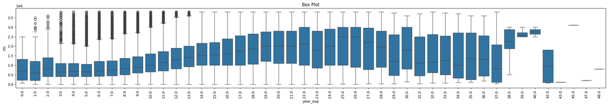

```python
fig=plt.figure(figsize=(100,4)) # width*height

# Set a range to exclude outliers (adjust as needed)
lower_limit = np.percentile(df['ctc'], 0)
upper_limit = np.percentile(df['ctc'], 95)

# Filter the data to exclude outliers
filtered_data = df[(df['ctc'] >= lower_limit) & (df['ctc'] <= upper_limit)]

# get top n categories
top_n = 120
top_categories = filtered_data["year_exp"].value_counts().nlargest(top_n).index

# filter the df
df_top_n = filtered_data[filtered_data["year_exp"].isin(top_categories)]

plt.subplot(1,3,1)
sns.boxplot(y='ctc', x='year_exp', data=df_top_n)

plt.xticks(rotation=90, ha='center')  # Rotate x-axis labels for better visibility

# Set labels and title
plt.xlabel("year_exp")
plt.ylabel('ctc')
plt.title(f'Box Plot')
```

- CTC seems to have noise after 40, so we'll be filtering the values till 40 years of exp.

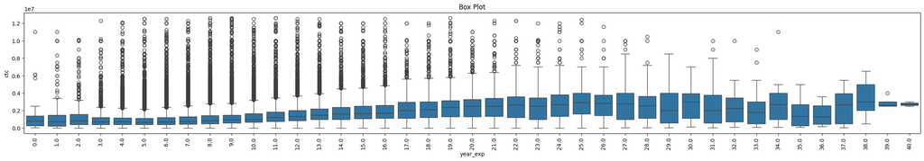

```python
df['year_exp'] = df['year_exp'].apply(lambda x: x if x<=40 and x>=0 else np.nan)

fig=plt.figure(figsize=(100,4)) # width*height

# Set a range to exclude outliers (adjust as needed)
lower_limit = np.percentile(df['ctc'], 0)
upper_limit = np.percentile(df['ctc'], 99)

# Filter the data to exclude outliers
filtered_data = df[(df['ctc'] >= lower_limit) & (df['ctc'] <= upper_limit)]

# get top n categories
top_n = 120
top_categories = filtered_data["year_exp"].value_counts().nlargest(top_n).index

# filter the df
df_top_n = filtered_data[filtered_data["year_exp"].isin(top_categories)]

plt.subplot(1,3,1)
sns.boxplot(y='ctc', x='year_exp', data=df_top_n)

plt.xticks(rotation=90, ha='center')  # Rotate x-axis labels for better visibility

# Set labels and title
plt.xlabel("year_exp")
plt.ylabel('ctc')
plt.title(f'Box Plot')
```

```python
df.head()
```

|  | company_hash | email_hash | orgyear | ctc | ctc_updated_year | year_exp |
| --- | --- | --- | --- | --- | --- | --- |
| 0 | atrgxnnt xzaxv | 6de0a4417d18ab14334c3f43397fc13b30c35149d70c05... | 2016.0 | 1100000 | 2020.0 | 8.0 |
| 1 | qtrxvzwt xzegwgbb rxbxnta | b0aaf1ac138b53cb6e039ba2c3d6604a250d02d5145c10... | 2018.0 | 449999 | 2019.0 | 6.0 |
| 2 | ojzwnvwnxw vx | 4860c670bcd48fb96c02a4b0ae3608ae6fdd98176112e9... | 2015.0 | 2000000 | 2020.0 | 9.0 |
| 3 | ngpgutaxv | effdede7a2e7c2af664c8a31d9346385016128d66bbc58... | 2017.0 | 700000 | 2019.0 | 7.0 |
| 4 | qxen sqghu | 6ff54e709262f55cb999a1c1db8436cb2055d8f79ab520... | 2017.0 | 1400000 | 2019.0 | 7.0 |

- email_hash and orgyear doesn't seems to be of any use for us

```python
df.drop(columns=["orgyear"], inplace=True, axis=1)
```

```python
df.info()
```

```
<class 'pandas.core.frame.DataFrame'>
RangeIndex: 205843 entries, 0 to 205842
Data columns (total 5 columns):
 #   Column            Non-Null Count   Dtype
---  ------            --------------   -----
 0   company_hash      205799 non-null  object
 1   email_hash        205843 non-null  object
 2   ctc               205843 non-null  int64
 3   ctc_updated_year  205843 non-null  object
 4   year_exp          205691 non-null  float64
dtypes: float64(1), int64(1), object(3)
memory usage: 7.9+ MB
```

```python
missing_value = round((df.year_exp.isnull().sum()/df.shape[0])*100 , 2)
print(f"year_exp missing value percentage: {missing_value}")

missing_value = round((df.company_hash.isnull().sum()/df.shape[0])*100 , 2)
print(f"company_hash missing value percentage: {missing_value}")
```

```
year_exp missing value percentage: 0.07
company_hash missing value percentage: 0.02
```

- Data seems missing let's merge and see the changes

```python
df.drop_duplicates(inplace=True)
```

```python
df.shape
```

```
(166861, 5)
```

```python
df.head()
```

|  | company_hash | email_hash | ctc | ctc_updated_year | year_exp |
| --- | --- | --- | --- | --- | --- |
| 0 | atrgxnnt xzaxv | 6de0a4417d18ab14334c3f43397fc13b30c35149d70c05... | 1100000 | 2020.0 | 8.0 |
| 1 | qtrxvzwt xzegwgbb rxbxnta | b0aaf1ac138b53cb6e039ba2c3d6604a250d02d5145c10... | 449999 | 2019.0 | 6.0 |
| 2 | ojzwnvwnxw vx | 4860c670bcd48fb96c02a4b0ae3608ae6fdd98176112e9... | 2000000 | 2020.0 | 9.0 |
| 3 | ngpgutaxv | effdede7a2e7c2af664c8a31d9346385016128d66bbc58... | 700000 | 2019.0 | 7.0 |
| 4 | qxen sqghu | 6ff54e709262f55cb999a1c1db8436cb2055d8f79ab520... | 1400000 | 2019.0 | 7.0 |

```python
df.email_hash.value_counts()
```

```
email_hash
c986600ef19093ce70837408516acac9570566a4b29b554cfb6b744ffbe697d6    3
db84980ad197f8eff08b14a3442ff57f6374ea780f2587b310aac54b6c32ee3a    3
e5960ec01a207bfa6b83d5576f3d66f98b95f2e200f250303027c95395e4bad9    2
607910ba90b77a948e9255d472b9281ce90e10bc2a3089fede923c0eb421d039    2
1ea4e620e2d1f02c6c546c1d263582badacdb4b783d4cb8660901d3940f7ac3b    2
                                                                   ..
611b800e5d0f4caae6ade0c0392d27590987e77237dc430a2dd7c95d8bb82fa4    1
14d7bfecc80ded3532b8cf37e5b20989448b5d3fe387862b0f295d3117056a5e    1
2fbd7838b0002973720ba4bf6775f07b63cf88373571273c350aaf4652f835fa    1
8fffb1aea12ae1dcf3ee1cfe2934117af26df3e989dae5b0580aaed826a46c8d    1
badb0e8acad3be3bddfee92367413ec947bbb1029826ffc3becaea02593a10f8    1
Name: count, Length: 153443, dtype: int64
```

```python
df[df["email_hash"]=="c986600ef19093ce70837408516acac9570566a4b29b554cfb6b744ffbe697d6"]
```

|  | company_hash | email_hash | ctc | ctc_updated_year | year_exp |
| --- | --- | --- | --- | --- | --- |
| 8695 | oyxc ozvd uqxcvnt rxbxnta | c986600ef19093ce70837408516acac9570566a4b29b55... | 1800000 | 2021.0 | 11.0 |
| 61154 | uvqrt | c986600ef19093ce70837408516acac9570566a4b29b55... | 3500000 | 2021.0 | 15.0 |
| 98347 | oyxc ozvd uqxcvnt rxbxnta | c986600ef19093ce70837408516acac9570566a4b29b55... | 1800000 | 2019.0 | 11.0 |

```python
# Find the index of the rows with the maximum 'Year' within each group
idx = df.groupby(['email_hash','company_hash'])['ctc_updated_year'].idxmax()

# Use the index to select the corresponding rows from the original DataFrame
df = df.loc[idx]

# Reset index for the final DataFrame
df.reset_index(drop=True, inplace=True)
```

```python
df[df["email_hash"]=="c986600ef19093ce70837408516acac9570566a4b29b554cfb6b744ffbe697d6"]
```

|  | company_hash | email_hash | ctc | ctc_updated_year | year_exp |
| --- | --- | --- | --- | --- | --- |
| 126055 | oyxc ozvd uqxcvnt rxbxnta | c986600ef19093ce70837408516acac9570566a4b29b55... | 1800000 | 2021.0 | 11.0 |
| 126056 | uvqrt | c986600ef19093ce70837408516acac9570566a4b29b55... | 3500000 | 2021.0 | 15.0 |

```python
df.shape
```

```
(160273, 5)
```

```python
df.email_hash.value_counts()
```

```
email_hash
db84980ad197f8eff08b14a3442ff57f6374ea780f2587b310aac54b6c32ee3a    3
e49d643e06c85681ee3b6feff020134f63c92b17e637283d44854412eb2c95fb    2
9c20e7a5e0b46a4350327978c130282184c2b39772405c5f5c9ab7e1e03b69e8    2
c88c616fb855fd35009d643fc4d9d91b4d53d363057fdc7fd071717c811296e6    2
e496afa17c48da3980dbd8330caf89ec01bd4d4849d17ad87a2b98abb699d172    2
                                                                   ..
57972fe710544a37de4ed56a1ac6f242d25d3f91cac5a4b787b840bea2c6fe30    1
57978d4cf69f3aa592a7a9a6eb5aecd0f5aa25005937befb846d16a6f6d4ae66    1
57983cc12ab513f649544370ad98a61a83e64a228a8d8b1a77c73cfc51b0b2e7    1
5798a70eb4780ddb0087a3c11ff7f6d7e23731ebf92dddeb3b7ca0b4f5c6df2d    1
5794bec6e3ee46ffdb464cd55aa9b34a1e5bc3fc05e52cd58570861bed8b8a88    1
Name: count, Length: 153411, dtype: int64
```

```python
df[df["email_hash"]=="db84980ad197f8eff08b14a3442ff57f6374ea780f2587b310aac54b6c32ee3a"]
```

|  | company_hash | email_hash | ctc | ctc_updated_year | year_exp |
| --- | --- | --- | --- | --- | --- |
| 137367 | vqwotqct | db84980ad197f8eff08b14a3442ff57f6374ea780f2587... | 700000 | 2021.0 | 4.0 |
| 137368 | vqwotqct xzaxv ogrhnxgzo rxbxnta | db84980ad197f8eff08b14a3442ff57f6374ea780f2587... | 700000 | 2021.0 | 4.0 |
| 137369 | zgn vuurxwvmrt | db84980ad197f8eff08b14a3442ff57f6374ea780f2587... | 400000 | 2019.0 | 4.0 |

```python
df.info()
```

```
<class 'pandas.core.frame.DataFrame'>
RangeIndex: 160273 entries, 0 to 160272
Data columns (total 5 columns):
 #   Column            Non-Null Count   Dtype
---  ------            --------------   -----
 0   company_hash      160273 non-null  object
 1   email_hash        160273 non-null  object
 2   ctc               160273 non-null  int64
 3   ctc_updated_year  160273 non-null  object
 4   year_exp          160134 non-null  float64
dtypes: float64(1), int64(1), object(3)
memory usage: 6.1+ MB
```

```python
missing_value = round((df.year_exp.isnull().sum()/df.shape[0])*100 , 2)
print(f"year_exp missing value percentage: {missing_value}")
```

```
year_exp missing value percentage: 0.09
```

- only .09% percent values seems to be missing we can drop the specific rows / perform imputing on that dataset.

```python
## Missing value treatment

from sklearn.impute import KNNImputer

numeric_columns = ["ctc", "year_exp"]

# Extract the numeric part of the DataFrame
df_numeric = df[numeric_columns]

# Impute missing values in the numeric part using KNNImputer
knn_imputer = KNNImputer(n_neighbors=20)
df_numeric_imputed = pd.DataFrame(knn_imputer.fit_transform(df_numeric), columns=numeric_columns)

# Combine the imputed numeric part with the original categorical part
df = pd.concat([df.drop(columns=numeric_columns), df_numeric_imputed], axis=1)
df.isnull().sum()
```

```
company_hash        0
email_hash          0
ctc_updated_year    0
ctc                 0
year_exp            0
dtype: int64
```

```python
df.shape
```

```
(160273, 5)
```

```python
df.drop(columns=["email_hash"], axis=1, inplace=True)
```

```python
df.head()
```

|  | company_hash | ctc_updated_year | ctc | year_exp |
| --- | --- | --- | --- | --- |
| 0 | bxwqgogen | 2019.0 | 3500000.0 | 12.0 |
| 1 | nqsn axsxnvr | 2020.0 | 250000.0 | 11.0 |
| 2 | gunhb | 2019.0 | 1300000.0 | 3.0 |
| 3 | bxwqgotbx wgqugqvnxgz | 2021.0 | 2000000.0 | 20.0 |
| 4 | fvrbvqn rvmo | 2018.0 | 3400000.0 | 15.0 |

```python
df.info()
```

```
<class 'pandas.core.frame.DataFrame'>
RangeIndex: 160273 entries, 0 to 160272
Data columns (total 4 columns):
 #   Column            Non-Null Count   Dtype
---  ------            --------------   -----
 0   company_hash      160273 non-null  object
 1   ctc_updated_year  160273 non-null  object
 2   ctc               160273 non-null  float64
 3   year_exp          160273 non-null  float64
dtypes: float64(2), object(2)
memory usage: 4.9+ MB
```

```python
## Outlier Treatment
'''
Based on our previous understanding we will be capping the values at 1% i.e. below 37,000 and above 1,26,00,000
'''

# Set upper and lower thresholds for capping (adjust as needed)
upper_threshold = 12600000
lower_threshold = 37000

# Apply capping to remove outliers
df['ctc'].clip(lower=lower_threshold, upper=upper_threshold, inplace=True)

df.shape
```

```
(160273, 4)
```

- Doesn't seems there exist any outlier after we did merging and filter the noise.

```python
df.head()
```

|  | company_hash | ctc_updated_year | ctc | year_exp |
| --- | --- | --- | --- | --- |
| 0 | bxwqgogen | 2019.0 | 3500000.0 | 12.0 |
| 1 | nqsn axsxnvr | 2020.0 | 250000.0 | 11.0 |
| 2 | gunhb | 2019.0 | 1300000.0 | 3.0 |
| 3 | bxwqgotbx wgqugqvnxgz | 2021.0 | 2000000.0 | 20.0 |
| 4 | fvrbvqn rvmo | 2018.0 | 3400000.0 | 15.0 |

```python
## Feature Engineering
'''
1. Calculated Years of experience using 'orgyear' features.
2. Based on Job Profile the data seems fine for clustering and Job Description seems not reliable as per understanding.
3. CTC_updated year: we will be considering the feature as categorical value.
4. Implementation of regex for the usecase doen't seems to be a good idea here.
'''

# Define bin edges and labels
bins = [0, 500000, 1500000, 3000000, float('inf')]  # 'inf' represents infinity, covering values greater than 120
bin_labels = ['Low', 'Medium', 'High', 'Very High']

# Create a new column 'Bins' and assign the bin labels
df['salary_bin'] = pd.cut(df['ctc'], bins=bins, labels=bin_labels, right=False)

# Define bin edges and labels
bins = [0, 5, 10, 50]  # 'inf' represents infinity, covering values greater than 120
bin_labels = ['Low', 'Medium', 'High']

# Create a new column 'Bins' and assign the bin labels
df['exp_bin'] = pd.cut(df['year_exp'], bins=bins, labels=bin_labels, right=False)
```

```python
# Define conditions and corresponding labels
conditions = [
    (df['ctc_updated_year'] == 2021),
    (df['ctc_updated_year'] == 2020),
    ((df['ctc_updated_year'] != 2020) & (df['ctc_updated_year'] != 2021))
]
labels = ['2021', '2020', 'other']
df['ctc_updated'] = np.select(conditions, labels, default='Other')
```

```python
df['ctc_updated'].value_counts()
```

```
ctc_updated
other    78368
2021     42742
2020     39163
Name: count, dtype: int64
```

```python
df.drop(columns=["ctc",'year_exp','ctc_updated_year'], axis=1, inplace=True)
```

```python
df.drop_duplicates(inplace=True)
```

```python
df.describe(include="all")
```

|  | company_hash | salary_bin | exp_bin | ctc_updated |
| --- | --- | --- | --- | --- |
| count | 66898 | 66898 | 66898 | 66898 |
| unique | 37299 | 4 | 3 | 3 |
| top | bxwqgogen | Medium | Medium | other |
| freq | 36 | 30519 | 33570 | 32612 |

```python
tmpdf = df.company_hash.value_counts().reset_index()
```

```python
for i in range(1,36):
    print(i, tmpdf[tmpdf["count"]==i].shape[0])
```

```
1 29137
2 3707
3 1418
4 748
5 487
6 346
7 271
8 172
9 129
10 135
11 103
12 99
13 70
14 70
15 37
```

[output cut: 20 more lines]

```python
# Count the occurrences of each category
category_counts = df['company_hash'].value_counts()

# Identify categories with count 1
single_occurrence_categories = category_counts[category_counts == 1].index

# Replace single-occurrence categories with 'Other'
df['company_hash'] = df['company_hash'].replace(single_occurrence_categories, 'Other')
```

```python
df.drop_duplicates(inplace=True)
```

```python
df.shape
```

```
(37797, 4)
```

```python
df.company_hash.value_counts()
```

```
company_hash
xzegojo                            36
bxwqgogen                          36
xmb                                36
Other                              36
vbvkgz                             36
                                   ..
hzxcvqxtnj                          2
btnnrtqngrtag xzntqzvnxgzvr xzw     2
hubw tzntquqxoto                    2
wvubvnqxd ntwyzgrgsj                2
x3 wgzohrnxzs                       2
Name: count, Length: 8163, dtype: int64
```

```python
df.describe()
```

|  | company_hash | salary_bin | exp_bin | ctc_updated |
| --- | --- | --- | --- | --- |
| count | 37797 | 37797 | 37797 | 37797 |
| unique | 8163 | 4 | 3 | 3 |
| top | xzegojo | Medium | Medium | other |
| freq | 36 | 16522 | 18909 | 16806 |

```python
df.describe().columns
```

```
Index(['company_hash', 'salary_bin', 'exp_bin', 'ctc_updated'], dtype='object')
```

```python
## Data preparation and Scaling

# OHE
df = pd.get_dummies(df,columns=['salary_bin', 'exp_bin', 'ctc_updated'], dtype=int)
```

```python
## Target Encoding
import category_encoders as ce
target_encoder = ce.TargetEncoder(cols=['company_hash']) # Create a TargetEncoder instance
df = target_encoder.fit_transform(df, df.index)  # Fit and transform the DataFrame with target encoding, using index as a dummy target

# Standard Scaler
from sklearn.preprocessing import MinMaxScaler
scaler = MinMaxScaler()

# Reshape the data to fit the scaler (required for a single column)
df["company_hash"] = scaler.fit_transform(df["company_hash"].values.reshape(-1, 1))
```

```python
df.head()
```

|  | company_hash | salary_bin_Low | salary_bin_Medium | salary_bin_High | salary_bin_Very High | exp_bin_Low | exp_bin_Medium | exp_bin_High | ctc_updated_2020 | ctc_updated_2021 | ctc_updated_other |
| --- | --- | --- | --- | --- | --- | --- | --- | --- | --- | --- | --- |
| 0 | 0.166218 | 0 | 0 | 0 | 1 | 0 | 0 | 1 | 0 | 0 | 1 |
| 1 | 0.000000 | 1 | 0 | 0 | 0 | 0 | 0 | 1 | 1 | 0 | 0 |
| 2 | 0.491054 | 0 | 1 | 0 | 0 | 1 | 0 | 0 | 0 | 0 | 1 |
| 3 | 0.788863 | 0 | 0 | 1 | 0 | 0 | 0 | 1 | 0 | 1 | 0 |
| 4 | 0.351813 | 0 | 0 | 0 | 1 | 0 | 0 | 1 | 0 | 0 | 1 |

```python
df.to_csv("dataset/phase2_df.csv", index=False)
```